# Question

Consider the $L$-system (and angle) defined below:

- Start: `B`
- Rules:  
  `A > [++XXBC][--XXBC][++++XXBC]`  
  `B > [-BA][+BA]`  
  `C > AB`  
  `X > XX`
- Number of recursions (number of iterations):
  - 6
- Angle
  - 45°

Please use [this online tool](https://draemm.li/various/fractals/l-systems/) to generate the pattern using “turtle graphics”.

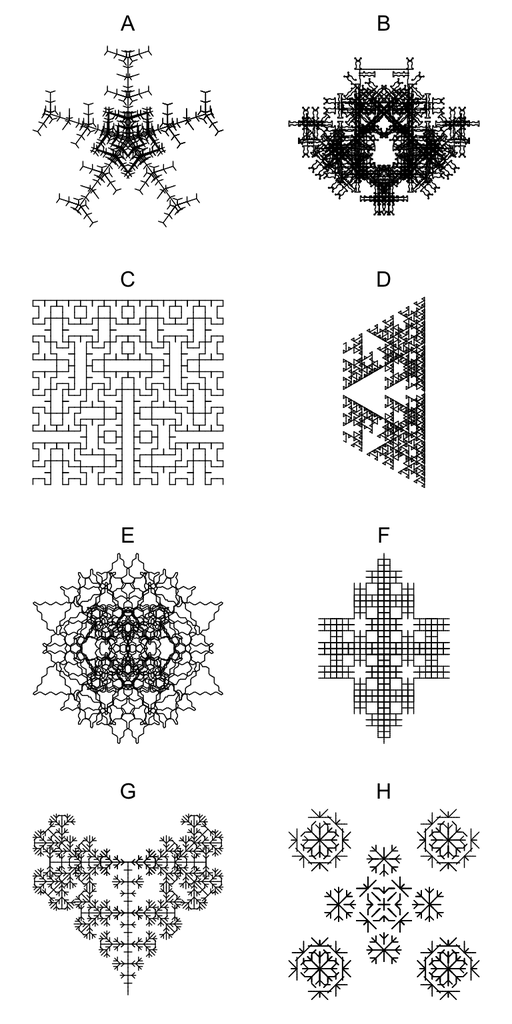

## Answerlist

- A
- B
- C
- D
- E
- F
- G
- H

# Solution

The correct pattern is pattern H.

1. Use the first link: https://draemm.li/various/fractals/l-systems/
2. Copy/paste the `Start`, `Rules`, `Angle`, and `Recursions`.
3. I usually start `Distance` at 1. It can be less than 1, like 0.1, if needed.
4. Click `Run!`
5. If necessary to make the pattern centered and scaled, adjust the `Start pos`, `Start angle`, and `Distance`.
6. Back to the quiz, select the matching pattern.

In case you’re interested in the parameters of the other patterns shown:

## Pattern A

- Start: `A+A+A`
- Rules:  
  `A > [+BCC][-BCC]`  
  `B > B[-CA][+CA]`  
  `C > CCA`
- Number of recursions (number of iterations):
  - 5
- Angle
  - 72

## Pattern B

- Start: `ABA`
- Rules:  
  `A > +B--A--B+`  
  `B > -A+BCB+A-`  
  `C > CC`
- Number of recursions (number of iterations):
  - 7
- Angle
  - 45

## Pattern C

- Start: `-A`
- Rules:  
  `A > +B-AA-B+`  
  `B > -A+BB+A-`
- Number of recursions (number of iterations):
  - 5
- Angle
  - 90

## Pattern D

- Start: `A`
- Rules:  
  `A > +B-AAA-B+`  
  `B > -A+BBB+A-`
- Number of recursions (number of iterations):
  - 5
- Angle
  - 120

## Pattern E

- Start: `AA`
- Rules:  
  `A > C--ABA+B+ABA--C`  
  `B > BA+C+AB`  
  `C > -B-CA++AC-B-`
- Number of recursions (number of iterations):
  - 4
- Angle
  - 30

## Pattern F

- Start: `A`
- Rules:  
  `A > ABA`  
  `B > [-BAB][+BAB]`
- Number of recursions (number of iterations):
  - 6
- Angle
  - 90

## Pattern G

- Start: `A`
- Rules:  
  `A > AB`  
  `B > A[++C][--C]`  
  `C > C[+C][-C]A`
- Number of recursions (number of iterations):
  - 7
- Angle
  - 45

## Pattern H

- Start: `B`
- Rules:  
  `A > [++XXBC][--XXBC][++++XXBC]`  
  `B > [-BA][+BA]`  
  `C > AB`  
  `X > XX`
- Number of recursions (number of iterations):
  - 6
- Angle
  - 45

# Meta-information

extype: schoice exsolution: 00000001 exname: lsys_pattern